# SMEs Scaling up in Italy: Country note

OECD, Centre for Entrepreneurship, SMEs, Regions and Cities (CFE)

2024-04-12

## Scalers and the economy

*A small group of SMEs that grow fast over a short period of time, i.e. “scalers”, provide a large part of the growth in jobs and economic value in OECD countries. This section contains an overview of the recent trends in the number of scalers in Italy and benchmark their contributions to job and value creation with other countries.*

### More than one fifth of Italian SMEs are scalers

In Italy, about 32 200 small or medium-sized enterprises (SMEs) became scalers between 2018 and 2021, accounting for 21% of the 150 000 SMEs in the non-financial business sector. Among those, about 15 200 were scalers in employment, 27 000 were scalers in turnover, and 10 000 were scalers in both employment and turnover.

Scalers in year 2020 are defined as enterprises with 10 to 249 employees (SMEs) that increased employment or turnover by at least 10% per year, on average, over the three previous years (2017-20). This means they grow by at least 33% over the three-year period.

The number of scalers in employment or in turnover grew by 80% from 2014 to 2019, reaching respectively 18 000 and 25 000. The number of turnover scalers declined sharply in 2020 as the COVID-19 pandemic spread. The number of scalers in employment fell as well, but less so. The reason is that SMEs that grew in 2018 and 2019 and were on track to become scalers by 2020 were unable to continue growing and might even had to reduce output or employment. The impact on turnover was more severe than on employment as generally firms tend to try to retain staff even through a crisis and particularly during the COVID-19 pandemic, Italy and most other OECD countries provided relief measures to support employee retention. In 2021, the number of scalers in turnover returned to the level of 2019, reflecting a quick recovery for many SMEs, in part supported by a large fiscal stimulus. Conversely, the count of scalers in employment remained stable, as persistent uncertainty deterred SMEs from committing to long-term investments in expanding their workforce.

High-growth scalers, defined as SMEs with annual growth rates exceeding 20% over three consecutive years, may exhibit distinct trends through economic cycles. Compared to other scalers, high-growth scalers may be faster to react to economic shifts and new market opportunities, but they may also be more constrained by lack of financial resources or tight labour markets. About one in three scalers grows by more than 20% per year on average over three consecutive years, qualifying as “high-growth” scalers. In Italy, in 2020 there were 4 900 high-growth scalers in employment and 6 100 high-growth scalers in turnover. The number of high-growth scalers in employment has been growing over time, starting from about 3 800 in 2013. High-growth scalers in turnover had a more volatile patterns, with a peak in 2012, followed by a decline in 2013-14 and a progressive recovery until the COVID-19 crisis.

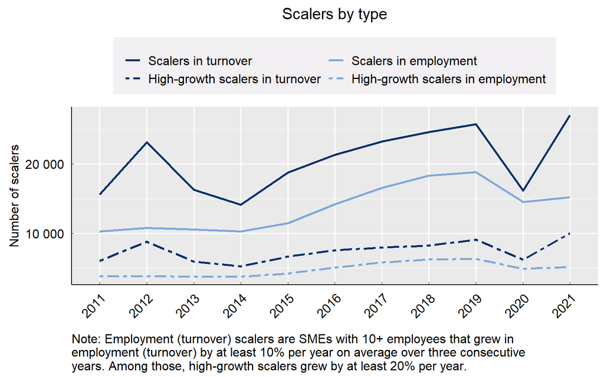

### Scalers in employment created 380 000 jobs over three years

In Italy, scalers in employment created 380 000 jobs over the 2017-20 period, which accounts to nine additional jobs for every 100 workers in SMEs in 2017. The contribution is aligned with the average of other countries for which data are available.

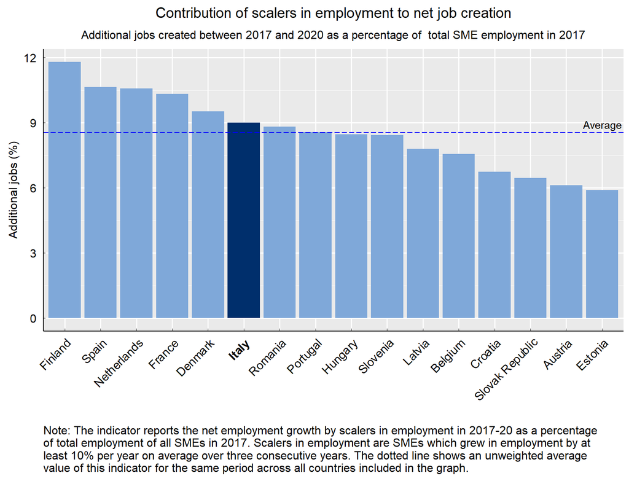

### The contribution of scalers in turnover was below the average of other countries

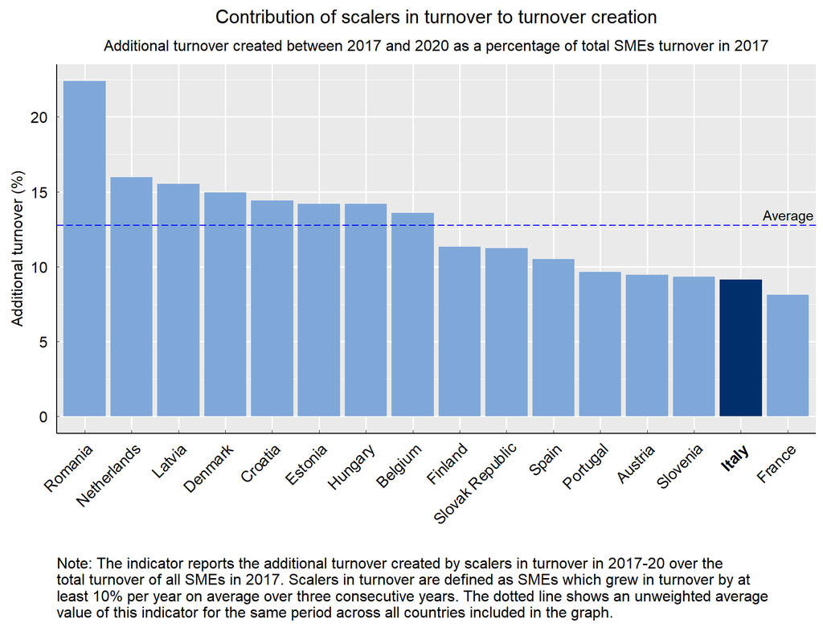

## Scalers’ characteristics

*All types of SMEs can scale up. This section describes the characteristics of scalers in terms of sector of activity, size, age, and geographical distribution. It also compares the likelihood of SMEs to scale up in Italy and in other countries across different groups of SMEs.*

### Italian SMEs operating in construction and advanced services are more likely to scale up

One out of five Italian scalers operate in medium-low tech manufacturing or in extractive industries. Non-tradable services (i.e., services that are mainly consumed locally) account for a similar share. The distribution of scalers across economic activities mirrors largely the distribution of SMEs across these activities.

However, in certain sectors scalers are more common compared to all SMEs, reflecting a higher likelihood of SMEs to scale up in these sectors. More than 30% of SMEs in the advanced tradable services sector or in construction become scalers, compared to 15% among SMEs operating in low or medium-low-tech manufacturing. Relative to other countries, Italian SMEs have a lower likelihood to become scalers in all sectors, especially in the manufacturing, and the education/social/health services sector.

Sector groups include the following two-digit NACE sectors:

• Low and medium-low technology manufacturing and extractive industries: food, textile, paper, wood, refined petroleum, rubber, plastic, basic metal products, mining.

• Medium-high and high technology manufacturing: chemical products, pharmaceuticals, computer, electronic/electrical equipment, machinery, transport equipment.

• Advanced tradable services: software, telecommunications, consultancy, legal services, accounting services, architectural activities, scientific research.

• Other tradable services: travel agency, services to buildings/landscape, employment activities, veterinary, accommodation/food services, services for transportation.

• Other non-tradable services: electricity, gas and water supply, waste management, wholesale and retail trade, repair of motor vehicles/household goods, real estate activities.

• Education, social care and health services: Education, human health activities, residential care, social work.

• Construction: construction of buildings, civil engineering, specialised construction activities.

Source: Manufacturing sectors are aggregated using Eurostat’s high-technology classification of manufacturing industries. The classification of tradable and non-tradable services is based on Piton, S. (2021). Economic integration and unit labour costs. European Economic Review, 136, 103746.

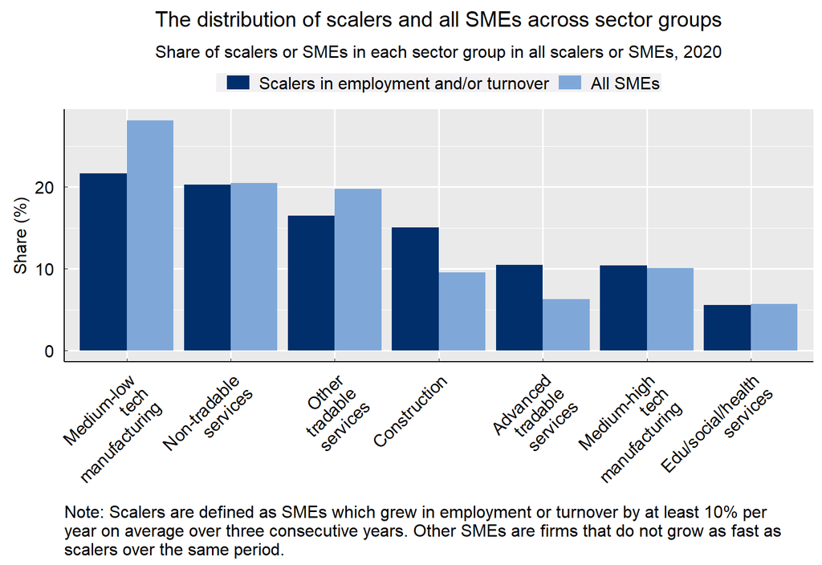

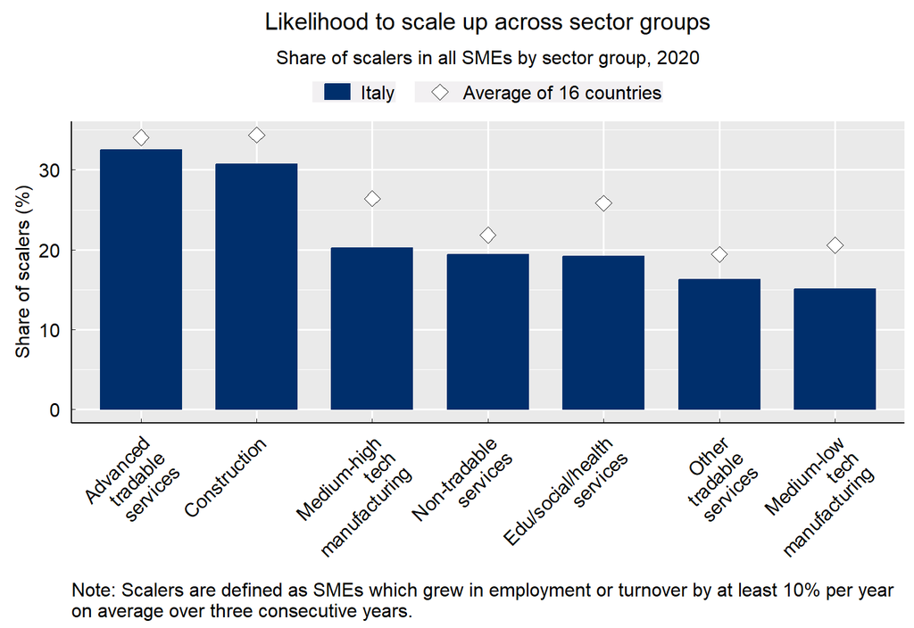

### SMEs across all size classes scale up

More than half of Italian scalers have between 10 and 19 employees at the beginning of the growth period, and almost one third have between 20 and 49 employees. Only 5% of scalers have between 100 and 249 employees before the expansion phase. The similar distribution of scalers and SMEs across size classes implies that the likelihood to scale up is not very different between smaller and larger SMEs. About 20% of SMEs in the 10-19 size class become scalers, compared to 18% of SMEs in the 100-249 size class. Differences in the likelihood to scale up across size classes in Italy are aligned with the cross-country averages.

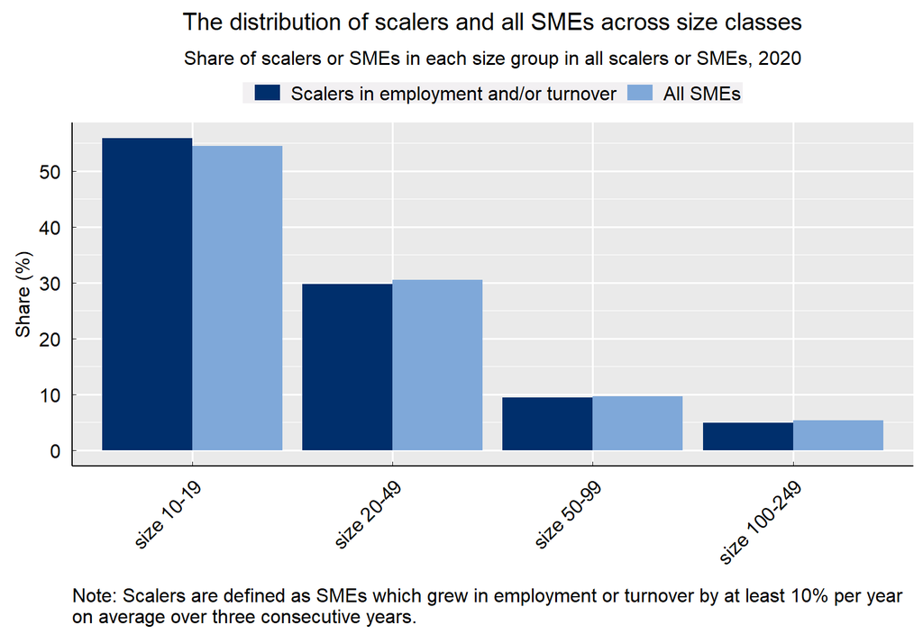

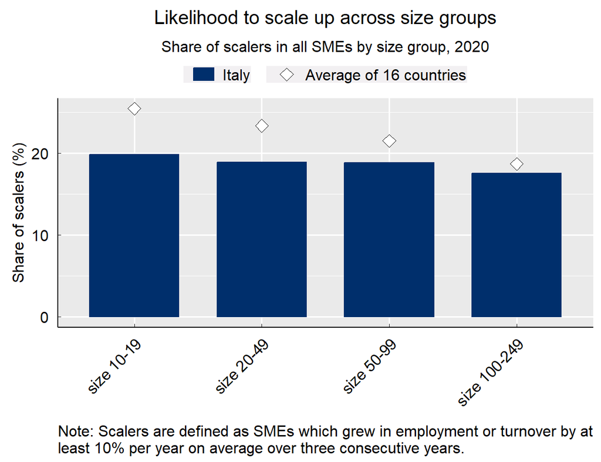

### Most of Italian scalers are mature SMEs

Most Italian scalers (56.5%) are mature SMEs that are more than 10 years old. 26% of scalers are less than 6 years old (i.e. young) and the rest (17.5%) are between 6 and 10 years old.

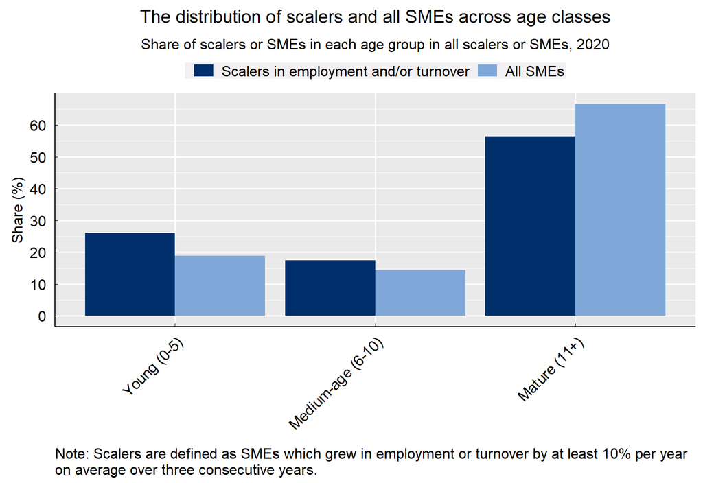

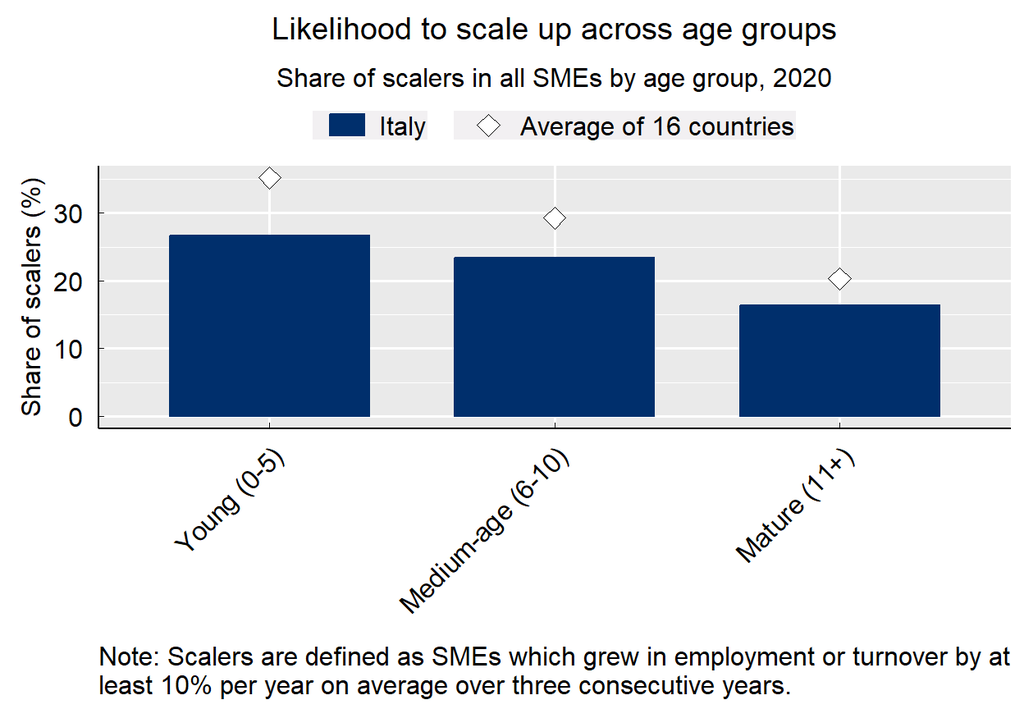

## Growth trajectories

*While many SMEs consolidate at their new size after scaling up, rapid growth also brings new challenges, with some scalers failing to adapt. This section illustrates the growth trajectories of scalers in the three years following their (first) expansion phase.*

### The majority of scalers maintained their new size or even continued to grow

About one in five scalers in continue on their high growth path. Between 2016 and 2019, 22% of Italian scalers in employment continued to scale up after a first scaling up in the previous three years. These 1 200 firms employed 58 000 more people after six years, with an increase in the workforce of 250%. The same share (22%) of scalers in turnover achieved two high-growth periods in a row, reaching a total turnover that was three times as large in 2019 as in 2013. In addition, 45% of scalers in employment and 45% of scalers in turnover maintained their size or grew moderately in the following three years. The share of scalers that consolidated at the new size or continued growing in Italy was very close to the average value across the other countries with available data.

### One in five scalers contracted after scaling up

Scaling up also brings challenges for SMEs. Firms may need to comply with stricter regulations, improve their managerial practices, or adopt a different financial model. Some scalers may struggle to adapt and reverse their growth. In Italy, 20% of SMEs that scale up in employment between 2013 and 2016 reduced their workforce over the following three years. Similarly, 22% of scalers in turnover had a lower turnover three years after scaling up, underscoring the challenges inherent in maintaining an expanded scale. Relative to other countries, the share of scalers experiencing a reversal was below average for scalers in employment, and aligned with the average for scalers in turnover.

### One in ten scalers was inactive three years after scaling up

For 11% of scalers, there was no information available on their employment or turnover levels in 2019. This lack of information is open to different interpretations. First, the firm may be closed or about to close, which in most cases indicates that the business has not been successful. Second, the company may have been acquired by another entity, which often indicates success rather than failure. Third, the lack of information may simply be a “nuisance” in the data, e.g. due to reporting errors. It is not possible to know the exact incidence of each of the three alternatives. However, it is known that acquisitions are rare events even for growth-oriented businesses. Conversely, around 8-10% of businesses close each year. Therefore, it is likely that most former scalers with missing information have ceased operations.

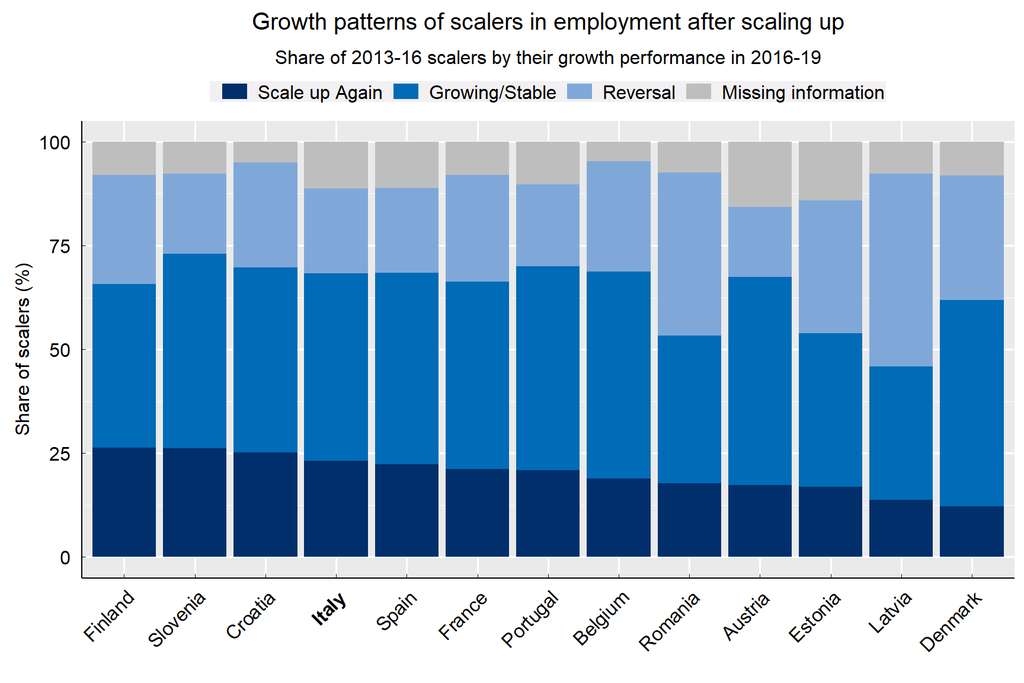

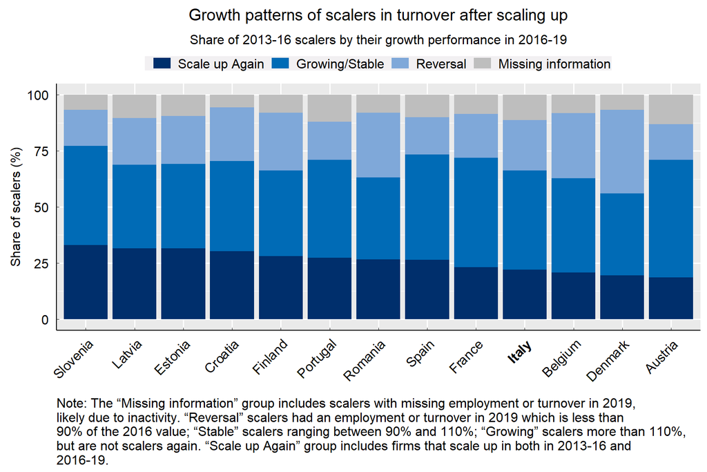